# R 실습 2일차

충남대학교병원 임상시험센터

구본초

2017-11-25

## **목적**

1. **R의 기본 연산 방법 둘러보기**
2. **주어진 데이터프레임으로 자료 전처리 방법을 알아보기**
3. **전처리한 자료를 바탕으로 `ggplot()` 기반 그래프를 만들어 보기**

## **R의 데이터 유형**

- R은 객체지향(object-oriented) 언어
- 객체(object): 숫자, 데이터셋, 단어, 테이블, 분석결과가 저장되는 모든 것들을 칭함

> **“객체지향”의 의미는 R의 모든 명령어는 객체를 대상으로 이루어진다는 것을 의미**

### 객체 할당(assignment)

객체를 할당 지시자: `=`, `<-`

> **R의 동작은 객체에 함수명령을 할당하는 방식으로 명령이 실행됨**
- 두 할당 지시자의 차이점
  - `=`: 명령의 최상 수준에사만 사용 가능
  - `<-`: 어디서든 사용 가능
- 예시에 사용한 함수
  - `rm()`: R workspace에 존재하는 객체 삭제 함수
  - `c()`: 벡터 생성 함수
  - `mean()`: 입력 벡터의 평균 계산 함수

```r
# 이전 히스토그램 생성 위해 생성한 x 삭제 `mean()` 입력
# 벡터의 평균 계산
my <- mean(y <- c(1, 2, 3, 4, 5))
mx <- mean(x = c(1, 2, 3, 4, 5))
# 실행결과
my
```

```
[1] 3
```

```r
mx
```

```
[1] 3
```

```r
y
```

```
[1] 1 2 3 4 5
```

```r
x
```

```
Error in eval(expr, envir, enclos): 객체 'x'를 찾을 수 없습니다
```

### 객체 명명 규칙

1. 알파벳, 한글, 숫자, `_`, `.`의 조합으로 구성 가능(`-`은 사용 불가)
2. 변수명의 알파벳, 한글, `.`로 시작 가능
   - `.`로 시작한 경우 뒤에 숫자 올 수 없음(숫자로 인지)
3. 대소문자 구분
4. 실습
   - 사용함수(프로토타입만 기술, 상세 함수 설명은 `help` 명령어로 확인)
     - `matrix(vector, nrow, ncol, byrow)`: 백터로부터 행렬 생성 함수 (참조: `help(matrix)`)
     - `seq(from, to, by)`: `from`에서 `to` 까지 `by` 간격으로 생성한 숫자열 반환 함수

> **참고** 문자열은 항상 큰 따옴표(`" "`) 안에 표기

```r
# 1:10은 1부터 10까지 정수 생성 'c()'는 벡터 생성 함수
x <- c(1:10)
# 1:10으로 구성된 행렬 생성
X <- matrix(c(1:10), nrow = 2, ncol = 5, byrow = T)
x
```

```
 [1]  1  2  3  4  5  6  7  8  9 10
```

```r
X
```

```
     [,1] [,2] [,3] [,4] [,5]
[1,]    1    2    3    4    5
[2,]    6    7    8    9   10
```

```r
# 논리형 객체
.x <- TRUE
.x
```

```
[1] TRUE
```

```r
# 알파벳 + 숫자
a1 <- seq(from = 1, to = 10, by = 2)
# 한글 변수명
가수 <- c("Damian Rice", "Beatles", "최백호", "Queen")
가수
```

```
[1] "Damian Rice" "Beatles"     "최백호"      "Queen"
```

> **주의:** 아래와 같이 객체명을 지정하면 오류!!

```r
3x <- 7
```

```
Error: <text>:1:2: 예상하지 못한 기호(symbol)입니다.
1: 3x
     ^
```

```r
_x <- c("M", "M", "F")
```

```
Error: <text>:1:1: 예상하지 못한 입력입니다.
1: _
    ^
```

```r
0.3 <- 10
```

```
Error in 0.3 <- 10: 대입에 유효하지 않은 (do_set) 좌변입니다
```

## R 객체

### 객체에 입력 가능한 값들

- **수치형(numeric)**: 숫자(정수, 소수)
- **문자열(string)**: `"충남대학교"`, `"R강의"`
- **논리형(logical)**: `TRUE`/`FALSE`
- **결측값(`NA`)**: 자료에서 발생한 결측 표현
- **공백(`NULL`)**: 지정하지 않은 값
- **요인(factor)**: 범주형 자료 표현(수치 + 문자 결합 형태로 이해하면 편함)
- **기타**: 숫자아님(`NaN`), 무한대(`Inf`) 등 수학적 표현(본 강의에서는 다루지 않음)

### 객체의 종류

- 스칼라(scalar)
- 벡터(vector): **R의 기본연산 단위**
- 행렬(matrix)
- 배열(array)
- 데이터프레임(data frame)
- 리스트(list)

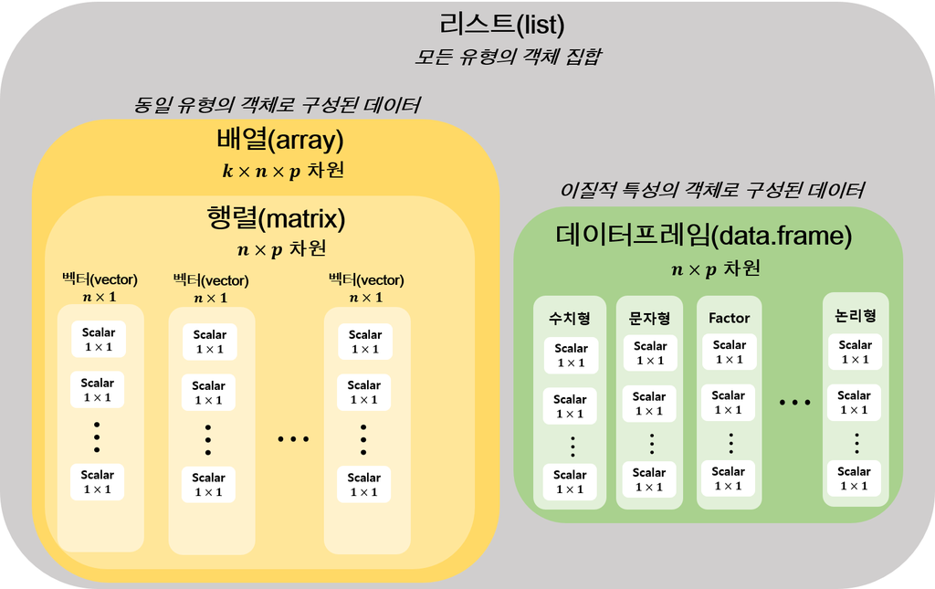

R 데이터 타입 구조 다이어그램: R, Python 분석과 프로그래밍 (by R Friend)에서 발췌 후 수정

## 스칼라(scalar)

1. 단일 차원의 값(하나의 값): $1 \times 1$ 벡터로 간주 가능
   - R 데이터타입의 기본은 벡터

> **참고: 스칼라를 입력시 R의 벡터 지정 함수인 `c()`를 꼭 사용해서 입력할 필요가 없다. 단, 두 개 이상 스칼라면 벡터이므로 꼭 c()를 써야 한다.**
2. 스칼라는 다음과 같은 값을 가질 수 있음

### 수치: 수치연산(`+, -, *, ^, **, /, %%, %/%`) 가능

```r
# 숫자형 스칼라
a <- 3
b <- 10
a
```

```
[1] 3
```

```r
b
```

```
[1] 10
```

```r
# 덧셈
c <- a + b
c
```

```
[1] 13
```

```r
# 뺄셈
d <- b - a
d
```

```
[1] 7
```

```r
# 곱셈
a * b
```

```
[1] 30
```

```r
# 멱승
b^a
```

```
[1] 1000
```

```r
b^a
```

```
[1] 1000
```

```r
# 나누기
b/a
```

```
[1] 3.333333
```

```r
# 나누기 나머지 반환
b%%a
```

```
[1] 1
```

```r
# 나누기 몫 반환
b%/%a
```

```
[1] 3
```

```r
# 연산 우선순위
n <- (3 + 5) * 3 - 4^2/2
n
```

```
[1] 16
```

### 문자값: 수치연산 불가능

```r
> h1 <- "Hello CNU Hospital CTC."
> g2 <- "R is not too difficult."
> h1
```

```
[1] "Hello CNU Hospital CTC."
```

```r
> g2
```

```
[1] "R is not too difficult."
```

```r
> h1 + g2
```

```
Error in h1 + g2: 이항연산자에 수치가 아닌 인수입니다
```

### 논리값

- `TRUE, T`: 참
- `FALSE, F`: 거짓
- `&, && (AND); |, || (OR); ! (NOT)` 연산자 사용 가능
- 비교연산 숫자값들의 비교를 통해 논리값 반환
  - `>, <, >=, <=, ==, !=`
  - 문자형 비교 연산은 `==, !=`만 가능

> **참고 1: 논리형 스칼라도 숫자형 연산 가능하다. 왜냐하면 컴퓨터는 TRUE/FALSE를 1과 0의 숫자로 인식하기 때문이다.**

> **참고 2: `&`와 `&&`는 동일하게 AND를 의미하지만 연산 결과가 다르다. `&`의 연산 대상이 벡터인 경우 백터 구성 값 각각에 대해 `&` 연산을 실행 하지만 `&&`는 한 개(스칼라)에만 논리 연산이 적용된다(아래 예시 참고).**

```r
> TRUE & TRUE
```

```
[1] TRUE
```

```r
> TRUE & FALSE
```

```
[1] FALSE
```

```r
> TRUE | TRUE
```

```
[1] TRUE
```

```r
> TRUE | FALSE
```

```
[1] TRUE
```

```r
> !TRUE
```

```
[1] FALSE
```

```r
> !FALSE
```

```
[1] TRUE
```

```r
> # T/F는 각각 TRUE/FALSE의 전역변수
> T <- FALSE
> T
```

```
[1] FALSE
```

```r
> TRUE <- FALSE
```

```
Error in TRUE <- FALSE: 대입에 유효하지 않은 (do_set) 좌변입니다
```

```r
> T <- TRUE
> # &와 &&의 차이
> l1 <- c(TRUE, TRUE, FALSE, TRUE)
> l2 <- c(FALSE, TRUE, TRUE, TRUE)
> l1 & l2
```

```
[1] FALSE  TRUE FALSE  TRUE
```

```r
> l1 && l2
```

```
[1] FALSE
```

```r
> x <- 10
> y <- 13
> x > y
```

```
[1] FALSE
```

```r
> x < y
```

```
[1] TRUE
```

```r
> x >= y
```

```
[1] FALSE
```

```r
> x <= y
```

```
[1] TRUE
```

```r
> x == y
```

```
[1] FALSE
```

```r
> x != y
```

```
[1] TRUE
```

```r
> y <- 10
> x != y
```

```
[1] FALSE
```

### 결측값

- 데이터 값이 없음을 의미
- 예를 들어 4명의 학생 중 3명의 수학 시험 점수가 80, 95, 90 점인데 한 학생의 점수를 모르는 경우 `NA`를 이용해 점수 표현
- `is.na()` 함수를 이용해 해당 값이 결측을 포함하고 있는지 확인

```r
one <- 80
two <- 95
three <- 90
four <- NA
four
```

```
[1] NA
```

```r
# 'is.na()' 결측 NA가 포함되어 있으면 TRUE 반환
is.na(NA)
```

```
[1] TRUE
```

### NULL 값

- 초기화 되지 않은 값 표현
- `is.null()` 함수를 통해 NULL 지정 여부 확인

> **참고: NA와 NULL은 다르다!!**

```r
> # NA와 NULL의 차이점 'is.null()' 객체 또는 변수에 NULL이
> # 저장되어 있는지 판단
> x <- NULL
> is.null(x)
```

```
[1] TRUE
```

```r
> is.null(1)
```

```
[1] FALSE
```

```r
> is.null(NA)
```

```
[1] FALSE
```

```r
> is.na(NULL)
```

```
logical(0)
```

### 요인값

- 범주형 자료를 표현하기 위한 값
- 범주형 자료
- 데이터가 사전에 정해진 특정 유형으로만 분류되는 경우 - 성별, 인종, 혈액형 등
  - 범주형 자료는 명목형과 순서형으로 구분 가능
    - 순서형 자료 예: 성적, 교육수준, 선호도, 중증도 등
- `factor()` 함수를 통해 표현 가능
  - 프로토타입: `factor(x, levels, labels, ordered)` (`help(factor)` 참조)
    - `x` 벡터(스칼라)에 대응하는 요인의 수준(`levels`)과 수준의 레이블(`levels`)을 지정. 만약 요인 `x`가 순서형이면 `ordered`인지 아닌지를 입력
  - 숫자형에 적용되는 연산 불가
  - 요인형을 조금 더 부연설명 하면 숫자 또는 문자 값에 수준의 속성을 부여한 값의 형태임
- 예시 사용 함수
  - `is.factor()`: 벡터(스칼라)가 요인형인지 확인
  - `nlevels()`: factor의 level 개수 반환
  - `levels()`: level 목록 반환
  - `labels()`: level에 대응하는 label 목록 반환
  - `ordered()`: 순서형 factor 생성
  - `is.ordered()`: 순서형 factor 확인

```r
> # factor() 기본 사용법 factor(x, levels, labels, ordered = F)
> # x: factor 형으로 지정하고자 하는 스칼라 또는 벡터 levels:
> # factor의 수준 지정 labels: factor의 레이블 지정
> sex <- factor("M", levels = c("M", "F"))
> sex
```

```
[1] M
Levels: M F
```

```r
> # factor 형 판단 TRUE/FALSE
> is.factor(sex)
```

```
[1] TRUE
```

```r
> # factor의 level 개수 반환
> nlevels(sex)
```

```
[1] 2
```

```r
> # factor의 level 목록 반환
> levels(sex)
```

```
[1] "M" "F"
```

```r
> # factor의 level 목록 수정
> levels(sex) <- c("Male", "Female")
> sex
```

```
[1] Male
Levels: Male Female
```

```r
> # 순서형 factor
> severity <- factor(1, levels = c(1, 2, 3), labels = c("Mild",
+     "Moderate", "Severe"))
> # severity <- ordered(severity) 또는 factor() 함수 내에서
> # ordered 옵션을 TRUE로 지정
> severity <- factor(1, levels = c(1, 2, 3), labels = c("Mild",
+     "Moderate", "Severe"), ordered = TRUE)
> severity
```

```
[1] Mild
Levels: Mild < Moderate < Severe
```

```r
> is.ordered(severity)
```

```
[1] TRUE
```

## 벡터

- 동일한 유형의 자료가 2개 이상 1차원 ($n \times 1$, $n \geq 2$) 으로 구성되어 있는 구조
- 벡터는 앞의 예시에서 본 바와 같이 `c()` 함수를 사용해 생성
- 서로 다른 자료형으로 벡터를 구성한 경우 표현력이 돞은 자료형으로 변환한 값 반환
  - 예: 문자열 + 숫자로 구성된 벡터 $\rightarrow$ 문자형 벡터
- 벡터 각 원소에 이름 부여 가능
  - `names()` 함수를 이용해 원소 이름 지정
    - 사용 프로토타입: `names(x) <- 문자열 벡터`, 단 `x`와 이름에 입력할 문자열 벡터의 길이는 같아야 함.
  - 벡터의 길이(차원) 확인
    - `length()` 또는 `NROW()` 사용
- 색인(indexing)을 통해 벡터의 원소에 접근 가능
  - `x[i]`: 벡터 `x`의 `i`번 째 요소
  - `x[-i]`: 벡터 `x`에서 `i`번 째 요소를 제외한 나머지
  - `x[I]`: `I`가 인덱싱 벡터라고 할 때 `I`에 지정된 요소를 얻어옴. 보통 `I`는 행번호 또는 각 원소의 이름을 표현하는 벡터
  - `x[start:end]`: `x`의 `start`부터 `end`까지 값 반환
- 벡터의 원소가 `NULL`을 포함한 경우 해당 원소가 완전히 삭제(예시 참조)

> **참고: 벡터 생성 시 알아두면 유용한 함수 `seq()`, `seq_along()`, `rep()` (예시 참조)**

> **`seq_along(x)`: `x`의 길이(length) 만큼 숫자 시퀀스 생성**

> **`rep(x, each, times)`: 벡터 x의 개별 원소를 `each`만큼 반복하거나 벡터 x 전체를 `times`만큼 반복 (예시 참조)**
- 예시 사용 함수
  - `is.numeric()`: 벡터가 숫자형인지 판단하는 함수
  - `is.character()`: 벡터가 문자형인지 판단하는 함수
  - `is.logical()`: 벡터가 논리형인지 판단하는 함수
  - `names()`: 객체의 이름 반환
  - `str()`: 객체의 속성구조 특징 반환

```r
# 숫자형 벡터
x <- c(1:25)
y <- c(26:50)
is.numeric(x)
```

```
[1] TRUE
```

```r
# 벡터의 연산 사칙연산
x + y
```

```
 [1] 27 29 31 33 35 37 39 41 43 45 47 49 51 53 55 57 59 61 63 65 67 69 71
[24] 73 75
```

```r
x - y
```

```
 [1] -25 -25 -25 -25 -25 -25 -25 -25 -25 -25 -25 -25 -25 -25 -25 -25 -25
[18] -25 -25 -25 -25 -25 -25 -25 -25
```

```r
x/y
```

```
 [1] 0.03846154 0.07407407 0.10714286 0.13793103 0.16666667 0.19354839
 [7] 0.21875000 0.24242424 0.26470588 0.28571429 0.30555556 0.32432432
[13] 0.34210526 0.35897436 0.37500000 0.39024390 0.40476190 0.41860465
[19] 0.43181818 0.44444444 0.45652174 0.46808511 0.47916667 0.48979592
[25] 0.50000000
```

```r
x * y
```

```
 [1]   26   54   84  116  150  186  224  264  306  350  396  444  494  546
[15]  600  656  714  774  836  900  966 1034 1104 1176 1250
```

```r
## 비교 연산
a <- c(1, 2, 3, 3, 4, 2, 5, 1, 2, 3, 4, 4, 4)
b <- c(2, 2, 4, 4, 3, 2, 5, 1, 2, 4, 4, 4, 3)
a > b
```

```
 [1] FALSE FALSE FALSE FALSE  TRUE FALSE FALSE FALSE FALSE FALSE FALSE
[12] FALSE  TRUE
```

```r
a >= b
```

```
 [1] FALSE  TRUE FALSE FALSE  TRUE  TRUE  TRUE  TRUE  TRUE FALSE  TRUE
[12]  TRUE  TRUE
```

```r
a < b
```

```
 [1]  TRUE FALSE  TRUE  TRUE FALSE FALSE FALSE FALSE FALSE  TRUE FALSE
[12] FALSE FALSE
```

```r
a <= b
```

```
 [1]  TRUE  TRUE  TRUE  TRUE FALSE  TRUE  TRUE  TRUE  TRUE  TRUE  TRUE
[12]  TRUE FALSE
```

```r
a == b
```

```
 [1] FALSE  TRUE FALSE FALSE FALSE  TRUE  TRUE  TRUE  TRUE FALSE  TRUE
[12]  TRUE FALSE
```

```r
a != b
```

```
 [1]  TRUE FALSE  TRUE  TRUE  TRUE FALSE FALSE FALSE FALSE  TRUE FALSE
[12] FALSE  TRUE
```

```r
# 벡터의 길이: `length()` 또는 `NROW` 함수 이용
z <- 1
length(z)
```

```
[1] 1
```

```r
NROW(x)
```

```
[1] 25
```

```r
# 문자형 벡터
str1 <- c("Boncho Ku", "Linear Regression", "307", "Male")
str1
```

```
[1] "Boncho Ku"         "Linear Regression" "307"
[4] "Male"
```

```r
# 벡터 원소의 이름 지정
names(str1) <- c("Name", "Subject", "Room", "Sex")
str1
```

```
               Name             Subject                Room
        "Boncho Ku" "Linear Regression"               "307"
                Sex
             "Male"
```

```r
is.numeric(str1)
```

```
[1] FALSE
```

```r
is.character(str1)
```

```
[1] TRUE
```

```r
# 숫자와 문자를 동시에 포함한 벡터라면?
vec1 <- c(1, 2, 5, "1", "Clinical Trial")
### 모두 문자열으로 변환된 벡터
# 논리형 벡터
boolen <- c(TRUE, TRUE, FALSE, TRUE, TRUE, TRUE, FALSE, FALSE)
is.numeric(boolen)
```

```
[1] FALSE
```

```r
is.logical(boolen)
```

```
[1] TRUE
```

```r
# 결측을 포함한 벡터
vecNA <- c(1:10, NA, NA)
is.na(vecNA)
```

```
 [1] FALSE FALSE FALSE FALSE FALSE FALSE FALSE FALSE FALSE FALSE  TRUE
[12]  TRUE
```

```r
is.numeric(vecNA)
```

```
[1] TRUE
```

```r
# NULL 포함 벡터
vecNULL <- c(NULL, 1, 2, NULL, 3)
vecNULL
```

```
[1] 1 2 3
```

```r
# seq_along(), rep() 함수 사용
seq_along(x)
```

```
 [1]  1  2  3  4  5  6  7  8  9 10 11 12 13 14 15 16 17 18 19 20 21 22 23
[24] 24 25
```

```r
z <- c(3, 8)
# `rep(x, each)` 사용 예
rep(z, each = 3)
```

```
[1] 3 3 3 8 8 8
```

```r
# `rep(x, times)` 사용 예
rep(z, times = 3)
```

```
[1] 3 8 3 8 3 8
```

```r
# `rep(x, each, times)` 사용 예
rep(z, each = 2, times = 3)
```

```
 [1] 3 3 8 8 3 3 8 8 3 3 8 8
```

```r
# 요인 벡터 rep() 함수를 이용한 0,1 벡터 생성
sex <- rep(c(0, 1), each = 10)
sex
```

```
 [1] 0 0 0 0 0 0 0 0 0 0 1 1 1 1 1 1 1 1 1 1
```

```r
sex <- factor(sex, levels = c(0, 1), labels = c("Male", "Female"))
sex
```

```
 [1] Male   Male   Male   Male   Male   Male   Male   Male   Male   Male
[11] Female Female Female Female Female Female Female Female Female Female
Levels: Male Female
```

```r
str(sex)
```

```
 Factor w/ 2 levels "Male","Female": 1 1 1 1 1 1 1 1 1 1 ...
```

```r
# 벡터의 색인
x[10]
```

```
[1] 10
```

```r
x[-3]
```

```
 [1]  1  2  4  5  6  7  8  9 10 11 12 13 14 15 16 17 18 19 20 21 22 23 24
[24] 25
```

```r
x[1:5]
```

```
[1] 1 2 3 4 5
```

```r
x[c(1:3, 10:12)]
```

```
[1]  1  2  3 10 11 12
```

```r
x[-c(1:10)]
```

```
 [1] 11 12 13 14 15 16 17 18 19 20 21 22 23 24 25
```

```r
str1["Name"]
```

```
       Name
"Boncho Ku"
```

### 벡터의 연산

위에서 기술한 연산자 이외, 알아두면 유용한 벡터 연산자들

1. 벡터는 숫자, 문자열 등 어떤 특정 값들의 묶음으로 볼 수 있기 때문에 집합 연산 가능
   - `identical(x, y)`: 객체 `x`와 객체 `y`가 동일한지 판단
   - `union(x, y)`: 객체 `x`와 객체 `y`의 합집합
   - `intersection(x, y)`: 객체 `x`와 객체 `y`의 교집합
   - `setdiff(x, y)`: 객체 `x`와 객체 `y`의 차집합
   - `x %in% y` :`y`에 `x`의 원소가 포함되어 있는지 판단

```r
x <- c(1:3)
y <- c(1:3)
identical(x, y)
```

```
[1] TRUE
```

```r
y <- c(1, 2, 4)
identical(x, y)
```

```
[1] FALSE
```

```r
union(x, y)
```

```
[1] 1 2 3 4
```

```r
intersect(x, y)
```

```
[1] 1 2
```

```r
setdiff(x, y)
```

```
[1] 3
```

```r
setdiff(y, x)
```

```
[1] 4
```

```r
x %in% y
```

```
[1]  TRUE  TRUE FALSE
```